# Homework2

Steven Black

2/12/2019

## Homework 2 for IS677 Intro to Data Science

1. The household data is part of a data set collected from a survey of household expenditure and give the expenditure of 20 single men and 20 single women on four commodity groups. The units of expenditure are Hong Kong dollars, and the four commodity groups are as follows:
- housing: housing, including fuel and light,
- food: foodstuff, including alcohol and tobacco,
- goods: other goods, including clothing, footwear and durable goods,
- service: services, including transport and vehicles.

The aim of the survey was to investigate how the division of household expenditure between the four commodity groups depends on total expenditure and to find out whether this relationship differs for men and women. Load the data into a data frame in R and use appropriate graphical methods to answer these questions and state your conclusions.

```r
household <- read.table("household.txt", header = TRUE, sep = ",")
```

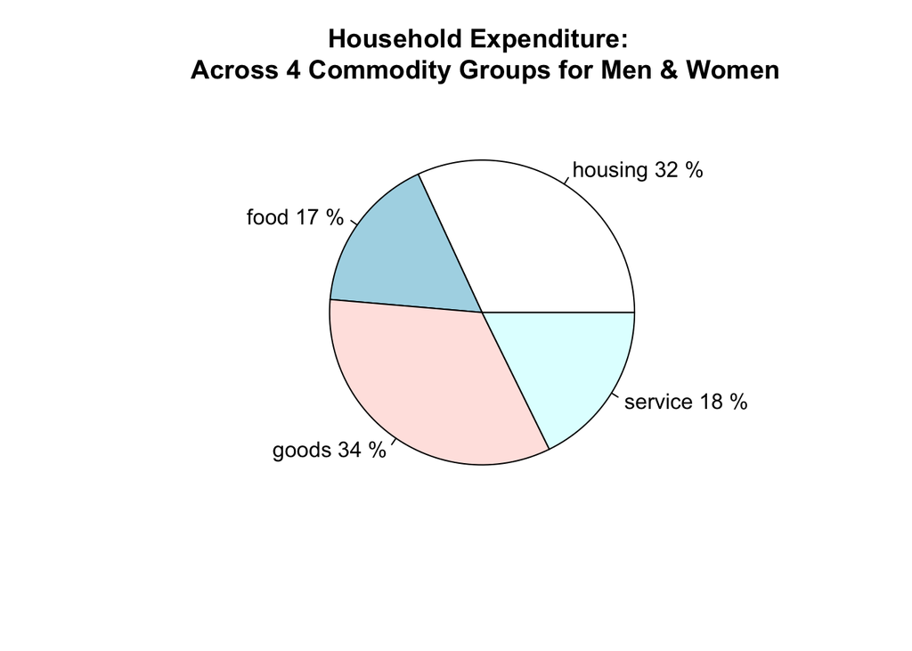

```r
group_sums <- colSums(household[,1:4])
pct <- round(group_sums/sum(group_sums)*100)
lbls <- paste(labels(group_sums), pct, "%")
pie(group_sums,
    main = "Household Expenditure: \n Across 4 Commodity Groups for Men & Women",
    labels = lbls)
```

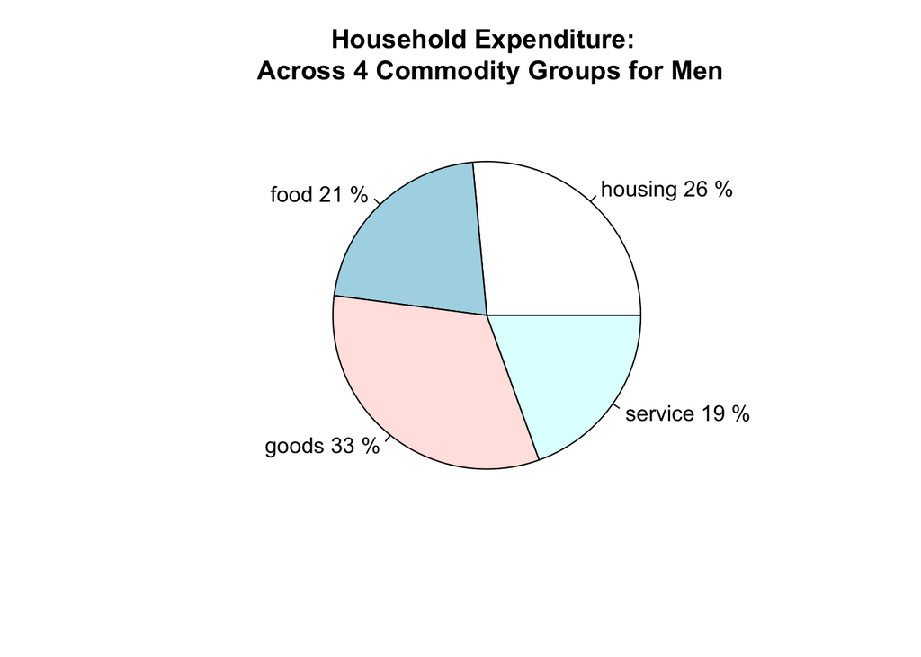

```r
groups_sums_grouped <- aggregate(. ~ household$gender, household, sum)
group_sums_men <- as.numeric(groups_sums_grouped[2, 2:5])
pct_men <- round(group_sums_men/sum(group_sums_men)*100)
lbls_men <- paste(labels(group_sums), pct_men, "%")
pie(group_sums_men,
    main = "Household Expenditure: \n Across 4 Commodity Groups for Men",
    labels = lbls_men)
```

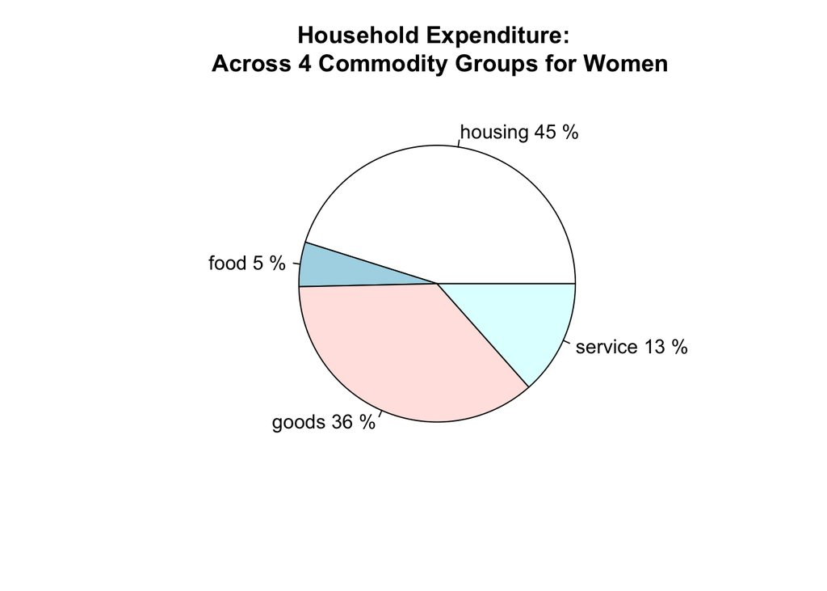

```r
group_sums_women <- as.numeric(groups_sums_grouped[1, 2:5])
pct_women <- round(group_sums_women/sum(group_sums_women)*100)
lbls_women <- paste(labels(group_sums), pct_women, "%")
pie(group_sums_women,
    main = "Household Expenditure: \n Across 4 Commodity Groups for Women",
    labels = lbls_women)
```

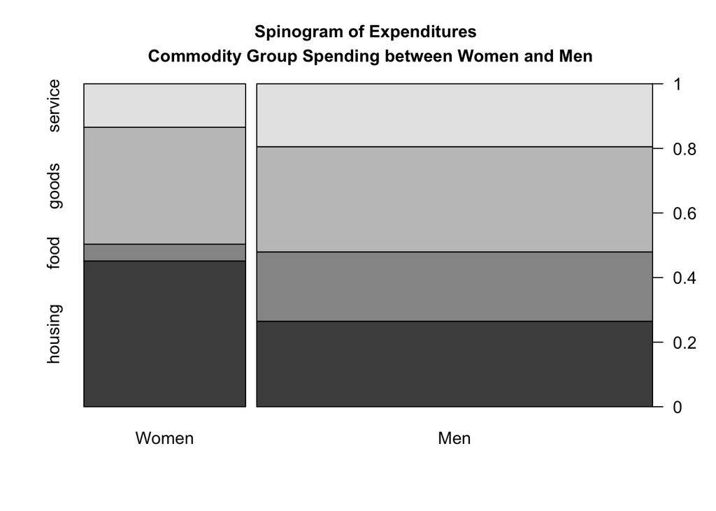

```r
library(vcd)
gsg <- groups_sums_grouped[2:5]
row.names(gsg) <- c("Women", "Men")
spine(as.matrix(gsg), main = "Spinogram of Expenditures \n Commodity Group Spending between Women and Men")
```

2. Mortality rates per 100,000 from male suicides for a number of age groups and a number of countries are provided in the suicides2 data set. Load the data into R and construct side-by-side box plots for the data from different age groups. Comment on what the graphic tells us about the data.